# R Bootcamp 2.2 Sampling & Distributions

last updated: 2021-10-11

## Sampling and distributions

> A curve has been found representing the frequency distribution of standard deviations of samples drawn from a normal population.

-Gosset. 1908, Biometrika 6:25.

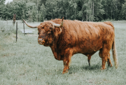

## What you will learn

- Use of the histogram
- Gaussian ain’t normal
- Poisson
- Binomial
- Diagnosing the distribution
- Practice exercises

## Use of the histogram

```r
# Let's simulate some fake weight data for 10,000 cats
set.seed(42)
cats <- rnorm(n = 10000, mean = 4, sd = 0.5)
```

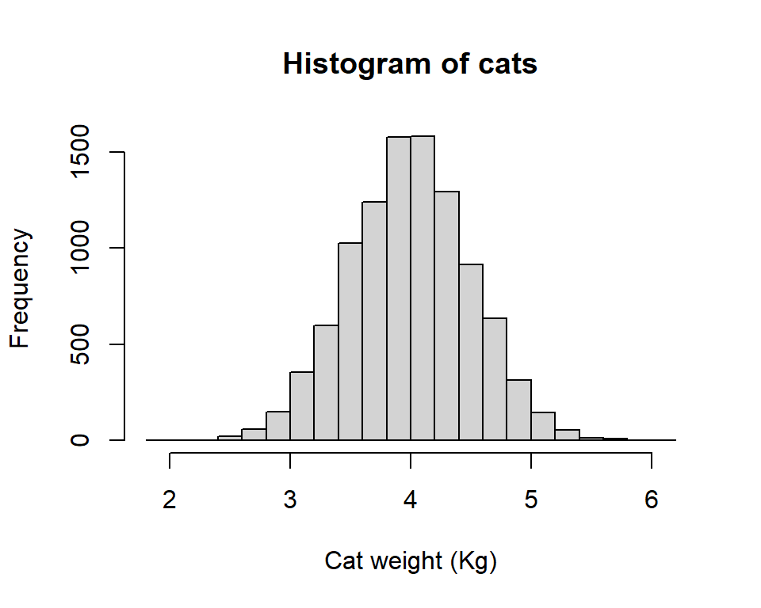

## Use of the histogram

- Bars are counts of observations
- ‘Bins’ non-overlapping
- Shape is diagnostic

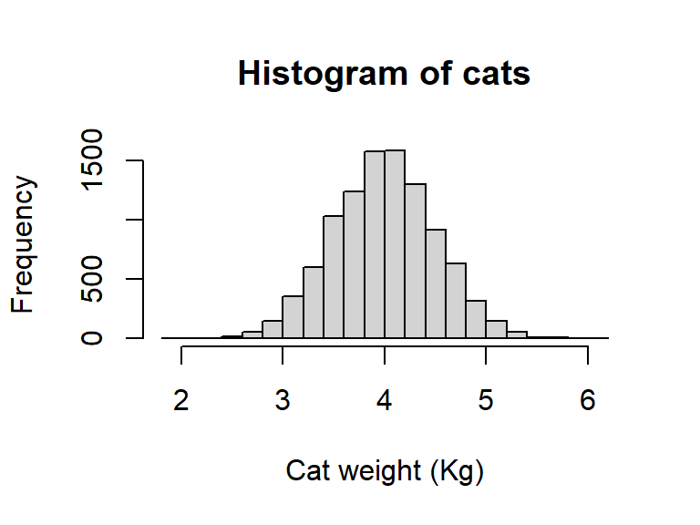

## Gaussian ain’t normal

Things you can measure with continuous precision

- The Gaussian is sometimes referred to as the ‘normal’ distribution
- Implies it is typical
- The Gaussian ain’t necessarily typical!
- Described by mean and std. dev. (the Gaussian parameters)

## Gaussian ain’t normal

Mean

```r
# Data
myvar <- c(1,4,8,3,5,3,8,4,5,6)

# Mean the "hard" way
(myvar.mean <- sum(myvar)/length(myvar))
```

```
## [1] 4.7
```

```r
# Mean the easy way
mean(myvar)
```

```
## [1] 4.7
```

## Gaussian ain’t normal

Standard Deviation

```r
# (NB this is the sample variance with [n-1])
(sum((myvar-myvar.mean)^2 / (length(myvar)-1)))
```

```
## [1] 4.9
```

```r
# Variance the easy way
var(myvar)
```

```
## [1] 4.9
```

```r
# Std dev the easy way
sqrt(var(myvar))
```

```
## [1] 2.213594
```

## Gaussian ain’t normal

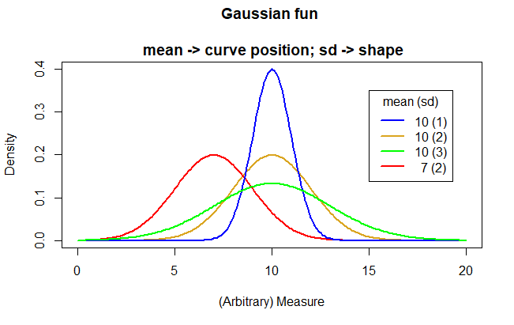

## Poisson

Counts of rare events (like deaths from being kicked by a horse in the Prussian army…)

## Poisson

```
set.seed(42)
mypois <- rpois(n = 100, lambda = 3)
hist(mypois,
     main = "Ewes with triplets",
     xlab = "Count of Triplets")
```

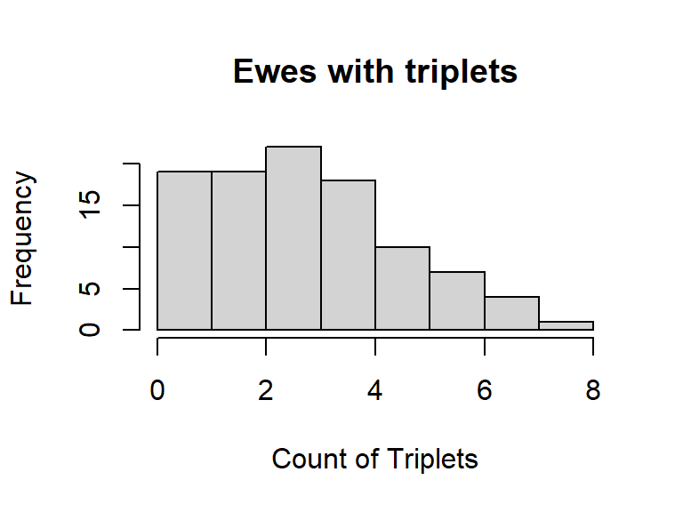

## Poisson

[figure not shown]

## Binomial

- Sometimes we are interested in the probability of success
- Described by 2 parameters, p{success}, and the number of trials

## Binomial

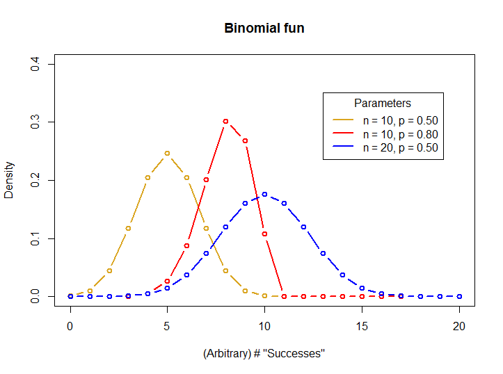

## Diagnosing the distribution

> A very common task faced when handling data is “diagnosing the distribution”. Just like a human doctor diagnosing an ailment, you examine the evidence, consider the alternatives, judge the context, and take a guess.

## Diagnosing the distribution

- Expectation based on the type of data
- Graph the data and look
- compare expected theoretical dist. with several known dist’s
- try transformation (e.g. to ‘coerce’ to Gaussian)

## Live coding

[figure not shown]